# Muscle RNAseq Power Analysis

# Power analysis for Muscle RNAseq

This notebook contains code for the power analysis for the RNAseq delta3 muscle experiment. Experiment design is two factor crossed, with Normal WT vs Crispr delta and Normal vs Deenervated. Number of expected samples per group is 5-6.

## Data

Data used is GSE58669 which is from (Macpherson, Farshi, and Goldman 2015). This contains two WT Innervated Soleus muscle samples and two WT Deenervated Soleus muscle samples. (Also some KO samples which we did not use for the analysis) FASTQ files were run through [Bioflows](https://github.com/compbiocore/bioflows) and counts made with HTseq. Specific genes of interest for the analysis came from email exchange, and Ensembl gene IDs were pulled with Biomart.

```r
# file parsing and cleaning
file_names <- c("SRS643406_SRX612440.dup.srtd.bam_htseq_counts", "SRS643403_SRX612437.dup.srtd.bam_htseq_counts",
    "SRS643407_SRX612441.dup.srtd.bam_htseq_counts", "SRS643404_SRX612438.dup.srtd.bam_htseq_counts")
types <- c("Innervated_WT_1", "Innervated_WT_2", "Denervated_WT_1", "Denervated_WT_2")
counts <- lapply(1:4, function(i) read.delim(file.path(file_names[i]), header = FALSE,
    col.names = c("gene_id", "gene_name", types[i]))) %>% reduce(full_join)
dataMat <- counts[, 3:6]
rownames(dataMat) <- counts$gene_id
head(dataMat)
```

|  | Innervated_WT_1 | Innervated_WT_2 | Denervated_WT_1 | Denervated_WT_2 |
| --- | --- | --- | --- | --- |
| ENSMUSG00000000001 | 370 | 481 | 799 | 917 |
| ENSMUSG00000000003 | 0 | 0 | 0 | 0 |
| ENSMUSG00000000028 | 35 | 49 | 100 | 109 |
| ENSMUSG00000000031 | 26525 | 56058 | 27610 | 74990 |
| ENSMUSG00000000037 | 2 | 12 | 1 | 38 |
| ENSMUSG00000000049 | 11 | 11 | 6 | 15 |

```r
genelist <- read.csv("gene_list.txt")
head(genelist)
```

|  | Gene.stable.ID | Gene.name | Gene.description |
| --- | --- | --- | --- |
| 1 | ENSMUSG00000092009 | Myh15 | myosin, heavy chain 15 [Source:MGI Symbol;Acc:MGI:3643515] |
| 2 | ENSMUSG00000027840 | Wnt2b | wingless-type MMTV integration site family, member 2B [Source:MGI Symbol;Acc:MGI:1261834] |
| 3 | ENSMUSG00000002384 | Bmp8b | bone morphogenetic protein 8b [Source:MGI Symbol;Acc:MGI:107335] |
| 4 | ENSMUSG00000027358 | Bmp2 | bone morphogenetic protein 2 [Source:MGI Symbol;Acc:MGI:88177] |
| 5 | ENSMUSG00000027796 | Smad9 | SMAD family member 9 [Source:MGI Symbol;Acc:MGI:1859993] |
| 6 | ENSMUSG00000021835 | Bmp4 | bone morphogenetic protein 4 [Source:MGI Symbol;Acc:MGI:88180] |

## Power analysis

RNAseqsamplesize (Zhao et al. 2018) was used to do the analysis. With expected fold change between groups = 2, FDR set = 0.01 and number of samples = 5, power was computed to be 0.086 for the selected genes of interest which is very low. Some gene IDs pulled from Biomart are not in the dataset because they are alleles on alternative sequences (i.e. rapsn and Fbxo32) Dispersion was also computed as 0.04754.

```r
# estimate gene read count and dispersion distribution
distribution <- est_count_dispersion(dataMat, group = c(0, 0, 1, 1))
```

```
## Disp = 0.04754 , BCV = 0.218
```

```r
# power estimation some gene IDs are not in dataset because they are alleles on
# alternative sequences (rapsn and Fbxo32)
power <- est_power_distribution(n = 5, f = 0.01, rho = 2, distributionObject = distribution,
    selectedGenes = genelist$Gene.stable.ID, storeProcess = TRUE)
mean(power$power)  # 0.08607387
```

```
## [1] 0.08607387
```

```r
power2 <- est_power_distribution(n = 6, f = 0.01, rho = 2, distributionObject = distribution,
    selectedGenes = genelist$Gene.stable.ID, storeProcess = TRUE)
mean(power2$power)
```

```
## [1] 0.1515883
```

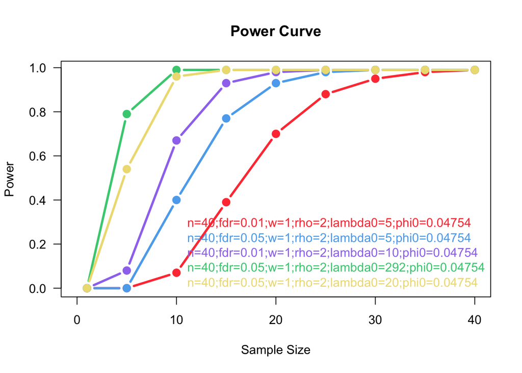

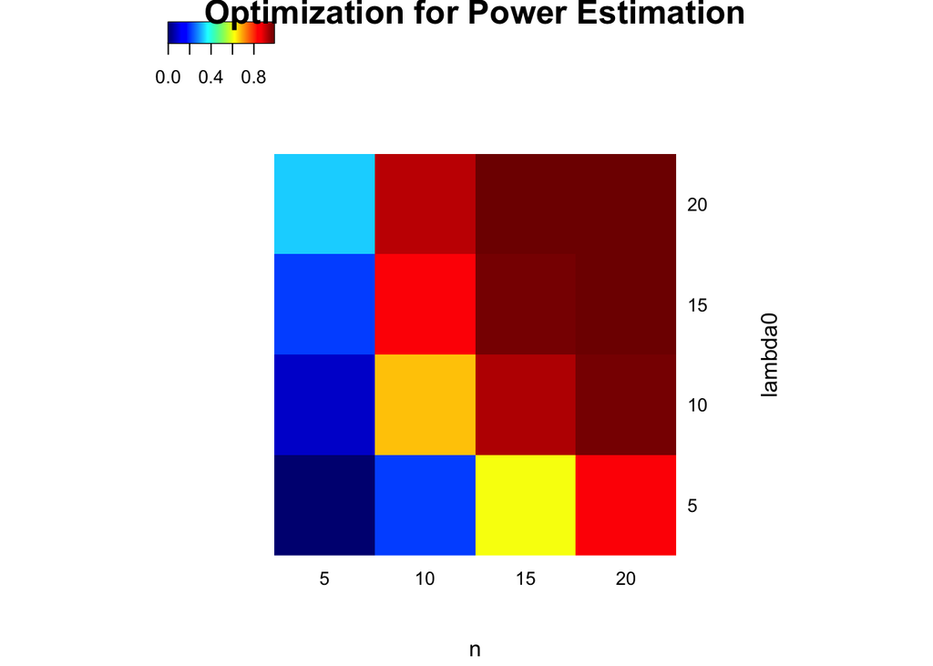

Blue to brown gradient shows power from 0 to 1. Here FDR=0.01.